# Defending the Climate Change/Wildfire Connection: A Guide for San Diego Climate Activists

Vivianna Plancarte

9/17/2020

## San Diego, “America’s Finest City”

Alongside Mexico and the Southern California coastline, possessing miles of ocean shoreline, forested hills, fertile valleys, mountains, canyons, and desert, San Diego’s diverse terrain and mild climate makes the region an attractive place to live or visit. Indeed, it’s coastal location along an international border has also allowed tourism, international trade, manufacturing, and military operations to flourish and develop the area economically.

Getting an average of 12 inches of rain per year, 0 inches of snow, and possessing average high temperatures ranging from 67 degrees Fahrenheit in January and 78 degrees in September (NOAA), San Diego has a mild Mediterranean climate characterized by cooler winters and dry summers. However, its distinct climate and terrain combined with population characteristics have caused it to be an especially vulnerable place for climate change induced warming, precipitation changes, droughts, and wildfires. In fact, within this year alone, 6 fires in San Diego have already burned 17,805 acres of land– a number already 1,459 acres more than burned last year from May until October (California Department of Forestry and Fire Protection (CAL FIRE)).

[figure not shown]

*Figure 1. A satellite image taken from Google Maps/Google Earth illustrates San Diego’s coastal location along the US-Mexico border and its topographic diversity. Composed of cities surrounded by shrublands and forests, the San Diego region is classified as a wildland-urban interface, or an area where fires can easily spread from forests or shrublands to neighborhoods.*

## The Important Role of Climate Activists

With fires burning all along the west coast from southern California to northern Oregon, debate about the role of climate change (or lack thereof) in these disasters has been highlighted by the media and national political conversations. In recent news, the president has been at opposite ends with other governmental leaders and scientists regarding the validity of climate change and climate change induced wildfires. In order to make progress on sustainable climate agendas, activists must be able to identify climate change fallacies which have been broadcasted by the media and should be prepared to actively refute them with research-backed evidence.

## Refuting Climate Change Fallacies

The president often makes fallacious claims by drawing conclusions on the basis of insufficient evidence in order to undermine the agendas of climate activists. For example, during a briefing on the California wildfires earlier this September, the president claimed, “I don’t think science knows” what’s actually happening (Baker et al, 2020). By ignoring the plethora of evidence which supports scientific consensus on climate change, the president attempts to impair the public’s understanding regarding the reality of climate change. However, with some familiarity of the recent study, “Consensus on consensus: a synthesis of consensus estimates on human-caused global warming”, activists could easily refute the president’s claim (Cook et al., 2016). The journal article reports that six independent studies have each found that 90-100% of publishing climate scientists endorse anthropogenic climate change, meaning there is strong evidence for overwhelming consensus among climate scientists that humans are causing global warming. Being aware of common arguments against climate change and evidence which refutes them is critical for climate activists to make progress on sustainable policy and initiatives.

Later, during this same briefing, the president again tactically jumped to conclusions and made a statement on insufficient evidence. To undermine the link between climate change and fires in California, the president insisted the fires were caused by poor forest management–not climate change–with no scientific evidence.

[figure not shown]

*Figure 2. The president’s assertion regarding the fires during the briefing this year echoed a tweet he posted in 2018, in which he publicly attributed the fires in California to poor forest management and threatened to withhold federal funds.*

This fallacy is particularly threatening because it may sound plausible to many people who do not know enough about forest management to refute the claim. Research on fire management would illuminate that the president’s claim is not entirely true. As Max Moritz, a wildfire specialist at the University of California, Santa Barbara points out, “These fires [those in Northern and Southern California] aren’t even in forests,” but began in areas known as wildland-urban interfaces–places where fires can easily spread from forests or grasslands to neighborhoods (Pierre-Louis 2018). Researchers have suggested that climate change has contributed to larger fires in these areas because warming temperatures dry vegetation quicker, which burns more easily (Flannigan et al. 2000). Fires in these areas are also the most destructive since they damage houses, other structures, and take lives. Furthermore, although the statement suggests that California’s state forest-management is to blame for the large and destructive fires, this could hardly be the case since most of California’s forests are federally owned.

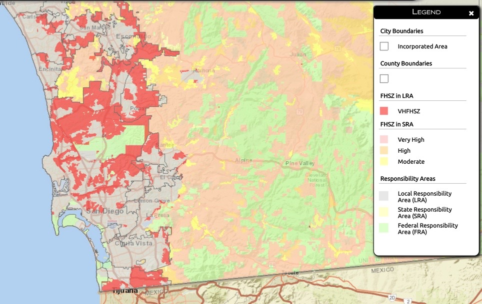

*Figure 3. The Fire Hazard Severity Zone maps (FHSZ) are provided by CAL FIRE to evaluate wildfire hazards, which are physical conditions that create a likelihood that an area will burn over a 30- to 50-year period. They also indicate local (FRA; grey), state (SRA; yellow), and federal responsibility areas (FRA; green). The map indicates that much of the forestland in the San Diego region (Cleveland National Forest) is classified as an FRA. .*

An in-depth understanding of how climate change is impacting San Diego’s temperatures during peak fire months and contributing to the fires can help climate activists refute fallacious arguments which undermine effective policy to address climate change. For this reason, I analyzed regional temperature data from NOAA (National Oceanic and Atmospheric Administration) from a weather station in San Diego, California (USW00023188). The NOAA provides a free archive of historical weather and climate data as well as station history from stations around the globe. The data reflect temperatures beginning July 1, 1939 (the earliest date that temperature data were available from the station) to August 29, 2020 (the most recent date that temperature data were available at the time of download).

## How is climate change impacting San Diego’s temperatures during peak fire months?

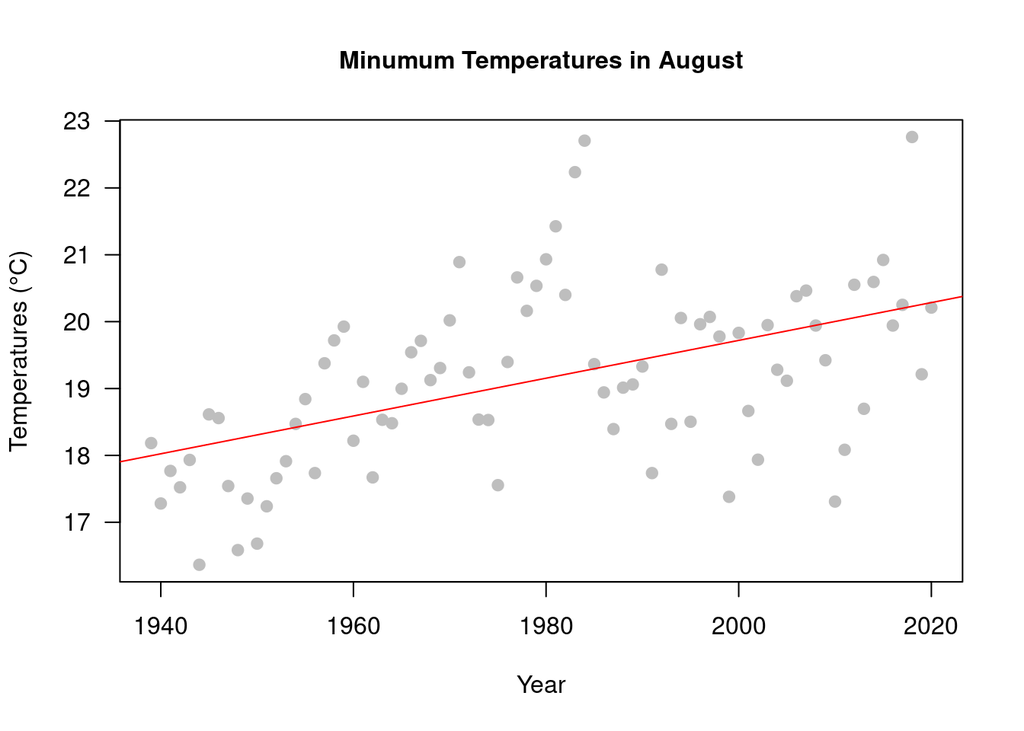

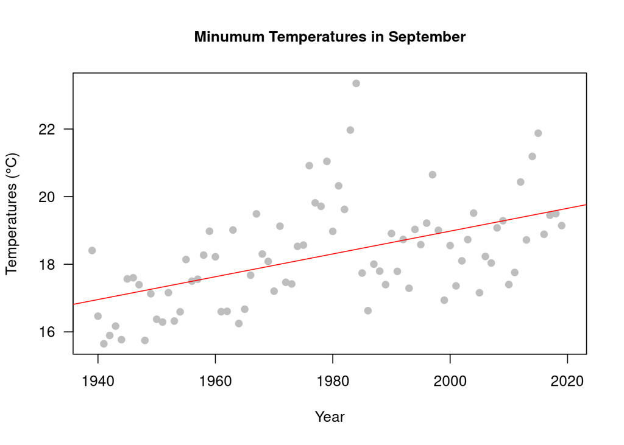

## Temperature Analysis Conclusions

Findings from these NOAA temperature analyses are in accordance with climate models developed by climate experts in partnership with the city of San Diego to explore how climate change and related issues are projected to impact the San Diego region by the year 2050 (Messner et al., 2011).The climate change projections widely used by local stakeholders are based on three climate models and two scenarios of energy use and greenhouse-gas (GHG) emissions which have been used in the IPCC’s 2007 climate assessment (A2 and B1).

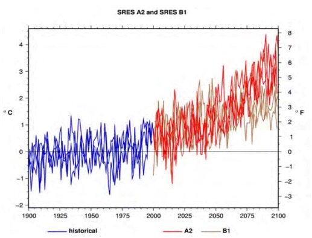

Figure 6. *The A2 emissions scenario (red) represents a future where high economic inequities between now industrialized and developing parts of the world persist, leading sustainable technology to spread slowly. The B1 scenario (brown) presents a future with high environmental consciousness and a global approach to climate change mitigation. The blue line represent historical temperature data*

All six simulations produced by Messner et al. (2011) predicted climatic warming over the next five decades in the San Diego region. Estimates of overall temperature increases range from 1.5°F to 4.5°F (0.8°C to 2.5°C), with greater warming in the summer than in winter. Additionally, all simulations predict hot daytime and nighttime temperatures (heat waves) would occur more frequently, with increased intensity and duration over the next 50 years. Findings from the NOAA data analysis reflect similar patterns. The data reveal increasing minimum temperatures for August and September which suggest that we may expect an increase in heat waves, or warmer temperatures during parts of the day that are usually cool, as time passes.

Messner et al. (2011) also predicted that although extreme warm temperatures mostly occur from July to August, as climate change continues, extreme warm temperatures would likely be seen sooner in the year (June) and last longer (September). The NOAA data confirm this prediction since they reveal that minimum temperatures in September are increasing, indicating that warm temperatures are lasting later into the year. It’s also important to note that the climate models predicted prolonged drought conditions would increase the likelihood of large wildfires in the San Diego region in the upcoming decades.

Knowing the information produced by this analysis will allow climate activists to refute claims denying climactic warming using reliable and scientificically assessed temperature data as well as produce more informed climate solutions.

## The Stakes are High for Everyone

Due to the consequences of climate change like heat waves, fires, and the economic and public health effects attached to them, it is especially critical that San Diegans have a shared understanding of anthropogenic climate change.

[figure not shown]

*Figure 7. The National Weather Service has issued a 4-day heat advisory for San Diego’s coast and inland valleys that is in effect from Oct. 13th-16th, 2020. The avdivsory alerts residents to temperature highs in the 80s near the coast and temperatures in the 90s for inland areas. The valleys will see temperatures around 100°F.*

Heat spells can have severely negative implications for public health and the regional economy. According to the National Oceanic and Atmospheric Administration (NOAA), heat waves are one of the deadliest weather-related events claiming hundreds of lives each year. Among the most vulnerable are young children under 5 years of age, elderly people 65 years and older, and those who are chronically ill (Knowlton et al. 2009; Iñiguez et al. 2010). Demographic projections estimate that nearly 25% of the region’s population, an estimated one million people, will be 65 years and older in 2050 (Messner et al. 2011). In an analysis of summer temperatures with no heat waves (1999-2003), epidemiologists found a 3% increase in deaths in any given day for a 10°F (5.6°C) increase in same-day temperatures (Basu et al. 2008). Thus, as climate change continues its course, San Diego’s aging population will likely face over a 3% increase in mortality events associated with warming temperatures.

Additionally, the San Diego Foundation’s Economic Resilience: Health Study, highlights the effects that increases in extreme heat may have on the region’s workforce and economy (2014). According to the study, approximately 220,000 workers are currently employed in heat-exposed industries such as construction, agriculture, transportation, and manufacturing. Current estimates show that $32 billion are generated for the region’s economy by this heat-exposed workforce. However, as the temperatures which employees work rise, it becomes increasingly more difficult for them to concentrate and work efficiently and lead to significant economic loss. The research suggests that 41 minutes of work time are lost from heat-exposed workers on days when peak temperatures are between 95- and 100-degrees Fahrenheit, and 58 minutes when temperatures exceed 100 degrees Fahrenheit. Thus, by 2050, it is predicted that 65,000 production hours, and a proportionate amount of revenue, will be lost to climate change. Moreover, maintaining worker health and productivity through air cooling is expected to increase commercial sector spending on electricity by 17 percent.

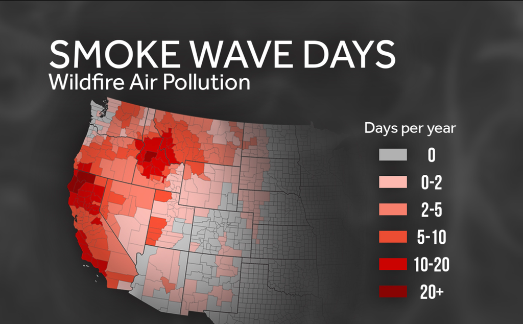

*Figure 8. Smoke wave days = a day with a PM2.5 concentration of at least 20 $u$g/$m^3$ (Lui et al. 2017). The map reveals that San Diego County is projected to have 5-10 more smoke wave days per year due to wildfire air pollution, however the number of days may have risen since the data was collected (2004-2009).*

Linked to the heatwaves, prolonged drought conditions and rises in temperatures were predicted to increase the likelihood of large wildfires in the San Diego region in the upcoming decades, especially during summer months such as August when temperatures are at their peak (Messner et al. 2011). Indeed rises in temperatures, as illustrated in the NOAA temperature graphs above, have likely contributed to the Volcano Fire this August and Valley Fire this September. The Valley Fire alone burned 16,390 acres, destroyed 61 and damaged 11 structures and clouded the skies with toxic fire smoke for three weeks southeast of Alpine in the San Diego region.

Wildfires can significantly impact public health and the economy by contributing to eye and respiratory tract irritation or more serious disorders, including reduced lung function, bronchitis, exacerbation of asthma and heart failure, and premature death. Containing numerous primary and secondary pollutants such as particulates, polycyclic aromatic hydrocarbons, carbon monoxide, aldehydes, organic compounds, gases and some inorganic materials with toxicological hazard potential (Künzli et al. 2006), wildfire smoke can have short- and long-term health implications when inhaled. In two studies conducted post the 2003 southern California wildfires, wildfire-related PM2.5 (fine inhalable particles, with diameters 2.5 micrometers or less) was found to be associated with a higher number of respiratory hospital admissions in the general population (Delfino et al. 2009) as well as increased eye and respiratory symptoms, medication use and physician visits among children (Kunzli et al. 2006). Moreover, a study which quantified the economic costs of health effects from the largest wildfire in Los Angeles County’s modern history estimated that the cost of illness associated with wildfire smoke is $9.50 per exposed person per day (Richardson et al. 2012).

## What can we do?

Because of the threats that climate change poses on the San Diego region’s economy, public health and overall environment, it is critical that climate activists approach their activism from various angles. Here are some actions climate activists can take to advance their pro-environmental agenda:

1. As highlighted in this blog, it is critical that climate activists, whether they be governmental leaders or members of the general public, are able to refute fallacious arguments regarding climate change. Although it may be effortful to stay informed on the latest climate research and arguments by climate change skeptics, this tactic will be worthwhile. Research has shown that merely talking about climate change can improve belief in climate change (Ballew et al. 2019). Conversations regarding climate change can become an even greater climate activist strategy if activists are able to debunk climate myths and provide research-based evidence.
2. As constituents of the United States government and stakeholders in the climate change crisis, eligible voters in the U.S. should elect representatives who do not deny the scientific consensus of climate change. Considering the upcoming general election, eligible voters should be ready to vote for governmental leaders who believe in climate change and take support pro-environmental climate policies.
3. Regardless of voting eligibility, individuals can do their part as climate activists by pushing sustainable initiatives and collaborating with regional sustainable organizations such as the Climate Science Alliance, San Diego Fire Recovery Network (SDFRN), and others which can be found at: http://www.sandiegoeco.org/collaborate/.

Although mitigating the public health, economic, and ecological effects of climate change is a complex issue, not all solutions are complex. Any climate activists can start by staying informed and debunking climate fallacies in day to day conversations.

## References

Baker P, Friedman L, Kaplan T. 2020. As Trump again rejects science, Biden calls him a ‘climate arsonist’ [Internet]. The New York Times. [cited 20 Oct 2020]. Available from: https://www.nytimes.com/2020/09/14/us/politics/trump-biden-climate-change-fires.html

Basu R, Feng WY, Ostro BD. 2008. Characterizing temperature and mortality in nine California counties. Epidemiology. [Internet]. [cited 14 Oct 2020];19(1). Available from: https://pubmed.ncbi.nlm.nih.gov/18091422/

California Department of Forestry and Fire Protection (CAL FIRE). 2020. [Internet]. [cited 14 Oct 2020]. Available at: https://www.fire.ca.gov/incidents/

Cayan DR, Bromirski PD, Hayhoe K, Tyree M, Dettinger MD, Flick RE. 2008a. Climate change projections of sea level extremes along the California coast: special issue on California climate scenarios. Clim Chang [Internet]. [cited 20 Sep 2020]; 87(Suppl 1). Available from: https://link.springer.com/article/10.1007/s10584-007-9376-7

Cook, J., Oreskes, N., Doran, P.T., Anderegg, W.R., Verheggen, B., Maibach, E.W., Carlton, J.S., Lewandowsky, S., Skuce, A.G., Green, S.A. and Nuccitelli, D. 2016. Consensus on consensus: a synthesis of consensus estimates on human-caused global warming. Environmental Research Letters. [Internet]. [cited 14 Oct 2020];11(4). Available from: https://iopscience.iop.org/article/10.1088/1748-9326/11/4/048002?platform=hootsuite

Delfino RJ, Brummel S, Wu J, Stern H, Ostro B, Lipsett M, Winer A, Street DH, Zhang L, Tjoa T, Gillen DL. 2009. The relationship of respiratory and cardiovascular hospital admissions to the southern California wildfires of 2003. Occup Environ Med [Internet]. [cited 20 Sep 2020]; 66(3). Available from: https://pubmed.ncbi.nlm.nih.gov/19017694/

Flannigan, Mike D., Brian D. Amiro, Kim A. Logan, Brian J. Stocks, and B. Mike Wotton. 2006. Forest fires and climate change in the 21 st century. Mitigation and adaptation strategies for global change. [Internet]. [cited 14 Oct 2020];11(4). Available at: https://link.springer.com/article/10.1007/s11027-005-9020-7

Flick, RE. 2014. San Diego, 2050 is calling. how will we answer? – facing the future: how science can help prepare San Diego regional leaders for climate change. Oceanogrphy Prog Pub [Internet]. [cited 20 Sep 2020]; [Internet]. [cited 20 Sep 2020]; Available from: https://escholarship.org/uc/item/9sb5f1s5 4.

Iñiguez CF, Ballester J, Ferrandiz S, Pérez-Hoyos M, Sáez AL. 2010. Relation between temperature and mortality in thirteen Spanish cities. Int J Environ Res Publ Health [Internet]. [cited 20 Sep 2020]; 7(8). Knowlton K, Rotkin-Ellman M, King G, Margolis HG, Smith D, Solomon G, Trent R, English P. 2009. The 2006 California heat wave: impacts on hospitalizations and emergency department visits. Environ Heal Perspect [Internet]. [cited 20 Sep 2020]; 117(7). Available from: https://pubmed.ncbi.nlm.nih.gov/19165388/

Kunzli, N., Avol, E., Wu, J., Gauderman, W.J., Rappaport, E., Millstein, J., Bennion, J., McConnell, R., Gilliland, F.D., Berhane, K. and Lurmann, F., 2006. Health effects of the 2003 Southern California wildfires on children. Am journal of respiratory and critical care medicine. [Internet]. [cited 14 Oct 2020];174(11). Available from: https://www.atsjournals.org/doi/full/10.1164/rccm.200604-519oc

Messner S, Miranda SC, Young E, Hedge N. 2011. Climate change-related impacts in the San Diego region by 2050. Clim Change. [Internet]. [cited 20 Sep 2020];109(S1). Available from: https://link.springer.com/article/10.1007/s10584-011-0316-1

NOAA (National Oceanic and Atmospheric Administration). 2020. Heat safety tips and resources. [Internet]. [Cited 20 Sep 2020.] Available from: https://www.weather.gov/safety/heat 10.

NOAA (National Oceanic and Atmospheric Administration). 2020. National weather forecast service office. [Internet]. [Cited 14 Oct 2020.] Available from: https://w2.weather.gov/climate/index.php?wfo=sgx

Pierre-Louis K. 2018. Trump’s Misleading Claims About California’s Fire ‘Mismanagement’. [Internet]. The New York Times. [cited 20 Oct 2020]. Available from: https://www.nytimes.com/2018/11/12/us/politics/fact-check-trump-california-fire-tweet.html

R Core Team. 2019. R: A language and environment for statistical computing. R Foundation for Statistical Computing,Vienna, Austria. [Cited 14 October 2020]. Available from: https://www.R-project.org/.

Richardson LA, Champ PA, Loomis JB. 2012. The hidden cost of wildfires: economic valuation of health effects of wildfire smoke exposure in southern California. J of Forst Econ. [Internet]. [cited 20 Sep 2020];18(1). Available from: https://www.sciencedirect.com/science/article/abs/pii/S1104689911000444

The San Diego Foundation (2014) Economic resilience: health. [Internet]. [cited 20 Sep 2020]. Available from: https://www.sdfoundation.org/wpcontent/uploads/2016/04/economic-resilience-health.pdf